# Spatial Regression Advanced Data Analytics

Jenna Atma

```r
packages <- c("biscale", "cleangeo", "cowplot", "dplyr", "geosphere",
            "ggplot2", "maps", "maptools", "rgdal", "rgeos", "sf",
            "sp", "spatialreg", "spdep", "tidyr")
sapply(packages, require, character.only=T)
```

[output not shown]

```
   biscale   cleangeo    cowplot      dplyr  geosphere    ggplot2       maps
      TRUE       TRUE       TRUE       TRUE       TRUE       TRUE       TRUE
  maptools      rgdal      rgeos         sf         sp spatialreg      spdep
      TRUE       TRUE       TRUE       TRUE       TRUE       TRUE       TRUE
     tidyr
      TRUE
```

# 1 Maryland

https://www.cnn.com/videos/great-big-story/2020/09/04/great-big-story-baltimore-trash-monster-project-planet-orig-gbs.great-big-story”

# 2 Dataset

```r
data <- read.csv('./Data/childpov18_southfull.csv',
                 colClasses = c("character", "character", "character",
                                "numeric", "numeric", "numeric", "numeric",
                                "numeric", "numeric", "numeric", "numeric",
                                "numeric", "numeric", "numeric", "numeric",
                                "numeric", "numeric", "numeric", "numeric",
                                "numeric", "numeric", "numeric", "numeric",
                                "numeric", "numeric", "numeric", "numeric",
                                "numeric", "numeric", "numeric", "numeric",
                                "numeric", "numeric", "numeric", "numeric"))

names(data)[names(data)=="X2016.child.poverty"] <- "child.pov.2016"
md_pov <- data %>% subset(State == "MD")
summary(md_pov)
```

```
     FIPS              State           County_Name          Longitude
 Length:24          Length:24          Length:24          Min.   :-79.27
 Class :character   Class :character   Class :character   1st Qu.:-77.00
 Mode  :character   Mode  :character   Mode  :character   Median :-76.61
                                                          Mean   :-76.67
                                                          3rd Qu.:-76.00
                                                          Max.   :-75.37
    Latitude     child.pov.2016   unemployment_13    per_lhs_13     per_black_13
 Min.   :38.13   Min.   : 5.800   Min.   : 4.800   Min.   : 5.10   Min.   : 0.793
 1st Qu.:38.54   1st Qu.: 9.575   1st Qu.: 5.975   1st Qu.: 8.70   1st Qu.: 9.227
 Median :39.11   Median :13.800   Median : 6.900   Median :10.90   Median :14.017
 Mean   :39.02   Mean   :16.071   Mean   : 7.304   Mean   :11.75   Mean   :19.752
 3rd Qu.:39.49   3rd Qu.:19.825   3rd Qu.: 8.200   3rd Qu.:14.20   3rd Qu.:24.243
 Max.   :39.62   Max.   :39.100   Max.   :12.600   Max.   :20.40   Max.   :63.338
 per_hispanic_13     per_ag_13      per_construction_13 per_manufacturing_13
 Min.   : 0.7996   Min.   :0.1282   Min.   : 5.061      Min.   : 2.409
 1st Qu.: 3.3978   1st Qu.:0.3042   1st Qu.: 6.650      1st Qu.: 4.844
 Median : 4.1969   Median :1.0699   Median : 7.651      Median : 6.115
 Mean   : 5.1345   Mean   :1.7077   Mean   : 7.760      Mean   : 6.531
 3rd Qu.: 5.5786   3rd Qu.:2.6315   3rd Qu.: 8.865      3rd Qu.: 8.148
 Max.   :17.4977   Max.   :7.2795   Max.   :10.672      Max.   :12.716
 per_retail_13    per_healthss_13 per_singlemom_13     urban            rural
 Min.   : 7.496   Min.   :17.77   Min.   : 6.555   Min.   :0.0000   Min.   :0
 1st Qu.: 9.438   1st Qu.:20.09   1st Qu.: 8.115   1st Qu.:1.0000   1st Qu.:0
 Median :10.406   Median :21.95   Median : 9.716   Median :1.0000   Median :0
 Mean   :10.500   Mean   :22.88   Mean   :10.527   Mean   :0.7917   Mean   :0
 3rd Qu.:11.160   3rd Qu.:25.11   3rd Qu.:11.195   3rd Qu.:1.0000   3rd Qu.:0
 Max.   :13.712   Max.   :30.60   Max.   :22.085   Max.   :1.0000   Max.   :0
   lnchildpov    lnunemployment     lnlesshs        lnblack         lnhispanic
 Min.   :1.758   Min.   :1.569   Min.   :1.629   Min.   :-0.232   Min.   :-0.2236
 1st Qu.:2.259   1st Qu.:1.788   1st Qu.:2.163   1st Qu.: 2.221   1st Qu.: 1.2224
 Median :2.625   Median :1.932   Median :2.389   Median : 2.640   Median : 1.4340
 Mean   :2.637   Mean   :1.959   Mean   :2.408   Mean   : 2.640   Mean   : 1.4459
 3rd Qu.:2.986   3rd Qu.:2.104   3rd Qu.:2.653   3rd Qu.: 3.187   3rd Qu.: 1.7189
 Max.   :3.666   Max.   :2.534   Max.   :3.016   Max.   : 4.148   Max.   : 2.8621
      lnag          lnconstruction  lnmanufacturing    lnretail       lnhealthss
 Min.   :-2.05397   Min.   :1.621   Min.   :0.879   Min.   :2.014   Min.   :2.877
 1st Qu.:-1.19132   1st Qu.:1.895   1st Qu.:1.578   1st Qu.:2.245   1st Qu.:3.000
 Median : 0.06316   Median :2.035   Median :1.811   Median :2.342   Median :3.089
 Mean   :-0.07201   Mean   :2.026   Mean   :1.800   Mean   :2.339   Mean   :3.119
 3rd Qu.: 0.96755   3rd Qu.:2.182   3rd Qu.:2.098   3rd Qu.:2.412   3rd Qu.:3.223
 Max.   : 1.98507   Max.   :2.368   Max.   :2.543   Max.   :2.618   Max.   :3.421
  lnsinglemom      lnchpov17      lnuninsured    lnincome_ratio  lnsevere_housing
 Min.   :1.880   Min.   :1.705   Min.   :1.961   Min.   :1.234   Min.   :2.536
 1st Qu.:2.094   1st Qu.:2.216   1st Qu.:2.208   1st Qu.:1.339   1st Qu.:2.632
 Median :2.271   Median :2.549   Median :2.444   Median :1.437   Median :2.728
 Mean   :2.306   Mean   :2.596   Mean   :2.408   Mean   :1.441   Mean   :2.765
 3rd Qu.:2.415   3rd Qu.:3.041   3rd Qu.:2.578   3rd Qu.:1.527   3rd Qu.:2.868
 Max.   :3.095   Max.   :3.622   Max.   :2.792   Max.   :1.817   Max.   :3.159
  lnteenbirth     lnunmarried
 Min.   :2.415   Min.   :2.760
 1st Qu.:3.118   1st Qu.:3.236
 Median :3.438   Median :3.459
 Mean   :3.482   Mean   :3.514
 3rd Qu.:3.888   3rd Qu.:3.778
 Max.   :4.261   Max.   :4.534
```

# 3 Oridnary Least Squares:

To test the relationship between child poverty and our independent variables we will start by running a simple OLS. This equation will be used to explain the level of child poverty by the list of variables and log variables in the dataset. We are also going to limit the use of scientific notation to numbers greater than 5 decimal places within the output and summaries.

```r
equation <- child.pov.2016 ~ rural + urban + lnmanufacturing + lnag +
  lnretail + lnhealthss + lnconstruction + lnlesshs +
  lnunemployment + lnsinglemom + lnblack + lnhispanic +
  lnuninsured + lnincome_ratio + lnteenbirth + lnunmarried
#Write as an object to keep from having to write it over and over

options(scipen = 5)

ols <- lm(equation, data=md_pov)
summary(ols)
```

```
Call:
lm(formula = equation, data = md_pov)

Residuals:
    Min      1Q  Median      3Q     Max
-3.7576 -1.3052  0.2018  1.1728  4.5810

Coefficients: (1 not defined because of singularities)
                Estimate Std. Error t value Pr(>|t|)
(Intercept)       0.3844    58.4073   0.007    0.995
rural                 NA         NA      NA       NA
urban             0.7783     4.6985   0.166    0.873
lnmanufacturing   4.7112     4.5168   1.043    0.327
lnag              1.1438     2.1983   0.520    0.617
lnretail        -12.3722    14.4748  -0.855    0.418
lnhealthss       -5.3008    13.3038  -0.398    0.701
lnconstruction   -2.7339     8.5134  -0.321    0.756
lnlesshs         19.2894    11.8282   1.631    0.142
lnunemployment    4.4074     7.4367   0.593    0.570
lnsinglemom      -2.4183    12.7800  -0.189    0.855
lnblack           3.3032     3.2156   1.027    0.334
lnhispanic       -3.0641     3.2213  -0.951    0.369
lnuninsured      -4.2786    11.1963  -0.382    0.712
lnincome_ratio    6.8168    23.1485   0.294    0.776
lnteenbirth       0.9064     2.8155   0.322    0.756
lnunmarried       0.3448     5.4729   0.063    0.951

Residual standard error: 3.804 on 8 degrees of freedom
Multiple R-squared:  0.938, Adjusted R-squared:  0.8217
F-statistic: 8.067 on 15 and 8 DF,  p-value: 0.002821
```

None of the independent variables show up as significant based on the OLS analysis. The model itself, however, has a p-value of 0.003. What this might suggest is that our dataset for child poverty in Maryland is probably not dependent on any of these factors spatially within the state, but perhaps the nature of Maryland’s closeness to several other nearby states and large cities (with large wealth inequalities, like Baltimore), could be having an influence of the model’s fit.

# 4 Moran’s Correlation Test

```r
#determining underlying spatial relationships in our residuals:
fips <- county.fips
fips.codes <- separate(data = fips, col = polyname, into = c("state", "county"), sep = ",")
md_fips <- subset(fips.codes, state=="maryland", select=fips)
```

```r
maryland <- map(database = "county", regions = "maryland", fill=T, plot=F)
md_sp = map2SpatialPolygons(maryland,md_fips$fips,CRS("+proj=longlat"))
#When running the next step of the process to create a list of neighbors for each county in the dataset, an error message stated that the polygons had invalid geometry. This means that when the data was digitized one of the polygons might not have been closed or there are overlapping vertices or lines. This can be repaired with the cleangeo package that somewhat acts like janitor but for spatial data.
```

```r
cleaned <- clgeo_Clean(md_sp)
```

[output not shown]

```r
neighb.data <- poly2nb(cleaned, queen=T)
cont.neighb <- nb2listw(neighb.data,style="W", zero.policy = TRUE)
#Now that we have created a spatial dataset and a list of neighbors, we can determine if there is any residual spatial dependence.
```

In this step we will use a Moran’s Correlation Test designed for regression residuals to examines the residuals of the OLS regression using the spatial relationship matrix. In this case the null hypothesis (HO) is “no spatial correlation in the residuals”.

```r
lm.morantest(ols, cont.neighb)
```

```
    Global Moran I for regression residuals

data:
model: lm(formula = equation, data = md_pov)
weights: cont.neighb

Moran I statistic standard deviate = 0.3672, p-value = 0.3567
alternative hypothesis: greater
sample estimates:
Observed Moran I      Expectation         Variance
     -0.10498509      -0.15879073       0.02147037
```

Non-significant p-value, which tells us that we don’t need some kind of spatial model for analysis. Just a regression analysis works to explain these data.

Just to check all possible spatial model types, we can run a SARMA hypothetical test. Most often, this kind of analysis isn’t very applicable. It runs all of the possible different types of models (seasonal auto-regressive moving)

```r
lm.LMtests(ols, cont.neighb, test="all")
```

```
    Lagrange multiplier diagnostics for spatial dependence

data:
model: lm(formula = equation, data = md_pov)
weights: cont.neighb

LMerr = 0.35338, df = 1, p-value = 0.5522


    Lagrange multiplier diagnostics for spatial dependence

data:
model: lm(formula = equation, data = md_pov)
weights: cont.neighb

LMlag = 0.01084, df = 1, p-value = 0.9171


    Lagrange multiplier diagnostics for spatial dependence

data:
model: lm(formula = equation, data = md_pov)
weights: cont.neighb

RLMerr = 0.78054, df = 1, p-value = 0.377


    Lagrange multiplier diagnostics for spatial dependence

data:
model: lm(formula = equation, data = md_pov)
weights: cont.neighb

RLMlag = 0.43801, df = 1, p-value = 0.5081


    Lagrange multiplier diagnostics for spatial dependence

data:
model: lm(formula = equation, data = md_pov)
weights: cont.neighb

SARMA = 0.79138, df = 2, p-value = 0.6732
```

The SARMA test agrees with my Moran’s test (non-significant), which means we can stop with the OLS model. This suggests that child poverty in the state of Maryland is not dependent on the spatial relationships between neighboring counties.

Spatial durbin = global effects Spatial durbin error = local effects

# 5 Mapping the results

```r
#dist.lag.data <- summary(all.dist.lag.k1, correlation=TRUE, Nagelkerke = TRUE)

dist.lag.output <- cbind.data.frame(md_pov$FIPS,
                                   md_pov$child.pov.2016,
                                    md_pov$lnmanufacturing,
                                    md_pov$lnblack,
                                    md_pov$lnlesshs,
                                    md_pov$lnhispanic,
                                    stringsAsFactors = FALSE)

#Renaming columns
colnames(dist.lag.output) <- c("fips","childpov",
                        "manufacturing","black","less_hs","hispanic")
```

```r
md_fortify <- fortify(md_sp)

md_poly <- merge(x = md_fortify, y = dist.lag.output,
                 by.x = "id", by.y = "fips", all = TRUE)

bivariate_data <- bi_class(md_poly, x = childpov, y = less_hs,
                           dim = 3, style = "quantile")

legend <- bi_legend(pal = "DkViolet",
                    dim = 3,
                    xlab = "Child Poverty",
                    ylab = "Less-than Highschool Education",
                    size = 6)
#Now that we have data and a legend, we need to create additional datasets to serve as a basemap for our analysis.

world <- map_data("world")
states <- map_data("state")
southern_states <- subset(states, region %in%
                            c("texas", "arkansas", "louisiana", "mississippi",
                              "alabama", "georgia", "florida", "north carolina",
                              "south carolina", "tennessee", "oklahoma",
                              "kentucky", "west virginia", "virginia",
                              "maryland", "delaware", "district of columbia"))
```

```r
mom_pov_map <- ggplot() +
  geom_polygon(data = world, aes(x=long,y=lat, group=group), fill = "gray95", color = "white") +
  geom_polygon(data = states, aes(x=long,y=lat, group=group), fill = "gray", color = "white") +
  geom_polygon(data = southern_states, aes(x=long,y=lat, group=group), fill = NA, size = 0.01, color = "white") +
  geom_polygon(data = bivariate_data, aes(x=long, y=lat, group=group, fill = bi_class), color = "grey50", show.legend = FALSE) +
  bi_scale_fill(pal = "DkViolet", dim = 3) +
  coord_map("conic", lat0 = 30, xlim=c(-79.6,-75), ylim=c(37.7,40)) +
  theme_void() + theme(legend.title.align=0.5) +
  theme(panel.background = element_rect(fill = 'deepskyblue'),
        panel.grid.major = element_line(colour = NA)) +
  labs(x = "Longitude", y = "Latitude", fill = "Child Poverty",
       title = "Bivariate Map of Child Poverty and Less-than Highschool Education") +
  theme(plot.title = element_text(face = "bold", hjust = 0.5))
```

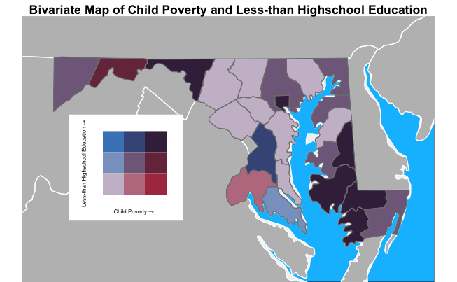

```r
final_map <- ggdraw() +
  draw_plot(mom_pov_map, 0, 0, 1, 1) +
  draw_plot(legend, 0.150, 0.030, 0.25, 0.75)
final_map
```